# Spatial distribution of RAM stocks

Jamie Afflerbach

March 2, 2016

This script uses [AquaMaps](http://www.aquamaps.org/) and the [RAM database](http://ramlegacy.org/) to identify stocks that are shared across multiple EEZs.

AquaMaps species range maps are used to spatially identify where stocks held in the RAM database are located. AquaMaps database was queried to select all species that match each stock in the RAM database that has a B/Bmsy value (using the `timeseries` database and filtering on `BdivBmsytouse-dimensionless` as the `tsid`). These species ranges are then split into stock ranges by using Ocean Health Index regions (EEZs and High Seas) that have been identified as covering the stock. This data can be found in `RAM/RAM_stocks_ohi_rgns.csv`.

### (0) Setup

```r
knitr::opts_chunk$set(warning=FALSE, message=FALSE)

library(data.table)
library(rgdal)
library(RColorBrewer)
library(raster)
library(dplyr)

cols      = rev(colorRampPalette(brewer.pal(11, 'Spectral'))(255)) # rainbow color scheme

dir_N = c('Windows' = '//neptune.nceas.ucsb.edu/data_edit',
          'Darwin'  = '/Volumes/data_edit',
          'Linux'   = '/var/data/ohi')[[ Sys.info()[['sysname']] ]]
```

### (2)Get RAM data

```r
#time series data is from version 3 of the ram database. Select those stocks that have B/Bmsy values

ts = read.csv('RAM/ram_timeseries.csv')%>%
  filter(tsid=='BdivBmsytouse-dimensionless') #selecting our assessment measure (B/Bmsy)

#RAM - OHI database from Kristen B.
ram = read.csv('RAM/RAM_stocks_ohi_rgns.csv')%>%
        rename(ohi_rgn = OHI_rgn,
               species = scientificname)%>%
        left_join(.,ts,by='stockid')

#list of ram species
ram_sp=unique(ram$species)
```

There are 246 unique scientific names in the RAM database.

### (3) Grab AquaMaps data

```r
am_sp = read.csv('aquamaps/speciesoccursum.csv')%>%
          mutate(fullname = paste0(genus," ",species))%>%
            filter(fullname %in% as.character(ram_sp))
am_cells = read.csv('aquamaps/hcaf_truncated.csv')

# am_sp_cells = fread(file.path(dir_N, 'git-annex/globalprep/_raw_data/aquamaps/v2015/csv/hcaf_sp_native_trunc.csv'),
#                     stringsAsFactors=F)%>%
#                  filter(speciesid %in% am_sp$speciesid)%>%
#                    write.csv(file='aquamaps/am_spp_cells_ram.csv')
am_sp_cells = read.csv('aquamaps/am_spp_cells_ram.csv')
```

After filtering the aquamaps species, it looks like 210 of the 246 RAM species are also in the AquaMaps database.

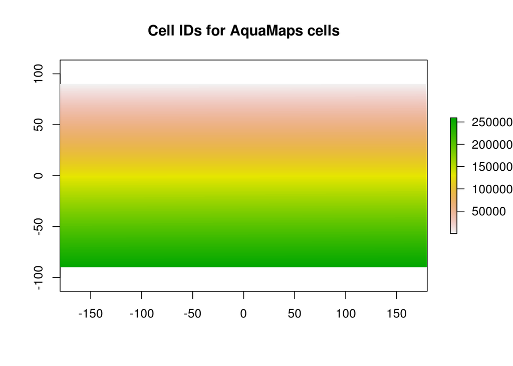

```r
cells_r = raster('spatial/loiczid_raster.gri')

plot(cells_r,main='Cell IDs for AquaMaps cells',box=F)
```

### (4) Rasterize EEZs (OHI regions) to the half degree cells, same as aquamaps. With rgn_id as zones

```r
eezs_r = raster('spatial/rgn_offshore_gcs.tif')%>%resample(.,cells_r,method='ngb',progress='text')
```

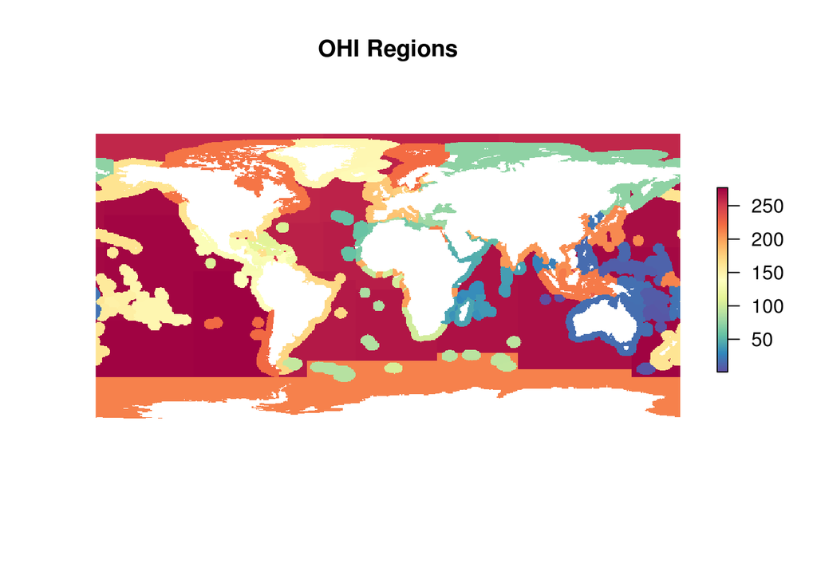

```r
plot(eezs_r,col=cols,main='OHI Regions',box=F,axes=F)
```

### (5) Rasterize each aquamap species, and then run zonal on each and get proportion of cells in each region

```r
### Species Map Function ###
# This function takes a single species scientific name as input, then grabs all occurrence cells and associated probability per cell

sp_map_fun <- function(species){

  sp = species

  sp_id  = filter(am_sp,fullname==sp)$speciesid
  sp_map = filter(am_sp_cells,as.character(speciesid)==as.character(sp_id))%>%
    merge(am_cells,by='loiczid')

  return(sp_map)
}
```

### (6) Create a database that has information for all RAM stocks including the proportion of species range found in each EEZ.

```r
#initialize empty dataframe
df = data.frame()

for (i in 1:nrow(am_sp)){

  #print(i)

  #get species name
  sp = am_sp[i,]$fullname

  #get the species map and set as data frame

  #I added a column 'presence' set to 1 and removed probability. For some species, like Thunnus obesus, there were duplicate
  # cells with different probabilities which is a problem for the subs() function below... not sure why there are duplicate
  # cells with different probabilities so this is one way around it. When we care about probability of occurrence, we will need
  # to find a better way (maybe take the average prob?)
  map  = sp_map_fun(sp)%>%as.data.frame()%>%
         mutate(presence = 1)%>%
          select(loiczid,presence)%>%
            unique()

  #substitute the species range map cells into the loiczid raster
  r_sp = subs(cells_r, map[,c('loiczid','presence')], by='loiczid', which='presence', subsWithNA=T)%>%
            mask(eezs_r) #masking the species map with the eez raster in order to remove those cells that are in the species range
                         # map but not included as 'ocean' cells in the eez map. This is not an ideal solution but will
                         #give a better proportion


  #get the total number of cells of the species range within each OHI region (zone)
  z = zonal(r_sp,eezs_r,fun='count',na.rm=T)

  #create the data we want - calculate the proportion of cells in each zone.
  d = as.data.frame(z)%>%
          filter(count>0)%>%
        mutate(species = sp,
               total_cells = ncell(r_sp) - freq(r_sp,value=NA),
               prop = count/total_cells)%>%
          rename(ohi_rgn = zone,
                 n_cells = count)

  df = rbind(d,df)
}
```

### (7) Add Country names to data frame

```r
rgns = read.csv('spatial/rgn_details.csv')%>%
        rename(ohi_rgn = rgn_id)%>%select(ohi_rgn,rgn_typ,rgn_nam)

spatialDF = df%>%
              left_join(.,rgns,by='ohi_rgn')%>%
              select(ohi_rgn,species,prop,rgn_typ,rgn_nam)%>%
            left_join(.,ram,by=c('species','ohi_rgn'))


write.csv(spatialDF,'ram_sp_prop_eezs.csv')
```

# Calculating stock proportions per EEZ/High Seas

Now we want to try and separate each species range into stocks. To do this, we are reducing the species range map to only include cells that have a probability of occurrence greater than or equal to **0.8**.

Then using the `RAM_stocks_ohi_rgns.csv’ data (database linking all stocks to OHI regions), each species range is split into the number of unique stocks for the species.

1. Species range is reduced to cells between 0.8 and 1
2. All stocks for a given species is identified from the RAM data
3. Each stock has a list of unique regions associated with the stock
4. These regions are rasterized and then used to mask the species range from step 1 in order to create a **stock range map**
5. The total proportion of the **stock range map** found in each EEZ is calculated.

**This is all done in the following for-loop:**

```r
out<-data.frame()

for (i in 1:nrow(am_sp)){

#1. select species
sp = am_sp[i,]$fullname

#2. get map of prob occurrence >=0.8

# for some species, like Thunnus obesus, there are duplicate loiczid reported with different probabilities... there is no
# obvious way to handle this as we dont know what probability is correct. I am simply taking the biggest...which is why the group_by and summarize
# are needed here
map <- sp_map_fun(sp)%>%filter(probability>=0.8)%>%
        group_by(loiczid)%>%
        summarize(probability = max(probability))%>%
        ungroup()%>%
        as.data.frame()


r_sp = subs(cells_r, map[,c('loiczid','probability')], by='loiczid', which='probability', subsWithNA=T)%>%
            mask(eezs_r)

#3. get unique stocks for the species

sp_stks = ram%>%
          filter(species==sp,
                 !is.na(tsvalue),
                 !is.na(ohi_rgn))%>%
            select(-tsid,-tsyear,-tsvalue)%>%
            distinct()

if(nrow(sp_stks)==0) next

#4. overlay eez map on species map and

uq_stks = unique(sp_stks$stockid)

stk_prop_df = data.frame()

#5. For loop to create distinct stocks per species and calculate proportion

for (j in 1:length(uq_stks)){
  #print(j)

  stkid = uq_stks[j]

  stkrgns = filter(sp_stks,stockid==stkid)%>%
              select(ohi_rgn)%>%
                collect()%>%
                .[['ohi_rgn']]

  rgn_eez <- eezs_r

  rgn_eez[!(rgn_eez %in% stkrgns)]<-NA

  #select only those cod cells that fall in the range of the stock regions

  stk_map <- mask(r_sp,rgn_eez)


#5. run zonal stats: get the total number of cells of the species range within each OHI region (zone)
z = zonal(stk_map,rgn_eez,fun='count',na.rm=T)

d = as.data.frame(z)%>%
          filter(count>0)%>%
        mutate(species = sp,
               total_cells = ncell(stk_map) - freq(stk_map,value=NA),
               prop = count/total_cells,
               stockid = stkid)%>%
          rename(ohi_rgn = zone,
                 n_cells = count)

#6. Combine all stocks per species into one dataframe
stk_prop_df = rbind(stk_prop_df,d)

}

#7. combine all stocks from all species
out = rbind(out,stk_prop_df)


}
```

Combine stock proportion dataframe with B/Bmsy information from RAM

```r
stk_prop = out%>%
            left_join(ram,by='stockid')%>%
              select(ohi_rgn = ohi_rgn.x,
                     species = species.x,
                     prop,stockid,commonname,areaid,
                     stocklong = stocklong.x,OHI_name,FAO,tsyear,tsvalue)

write.csv(stk_prop,file='RAM_stocks_per_ohi_rgn.csv')

#prop_map = subs(eezs_r,d[,c('ohi_rgn','prop')],by='ohi_rgn',which='prop')
```

Get all species that are found in more than 1 EEZ

```r
d <- stk_prop%>%
  group_by(stockid,species,commonname,stocklong,areaid)%>%
  summarize(count = length(unique(ohi_rgn)))%>%
  filter(count>1)
```

Looks like there are 116 that have a B/Bmsy in the RAM database AND have assigned an OHI region. There are just 21 stocks in the RAM database that meet our conditions.

```r
knitr::kable(d)
```

| stockid | species | commonname | stocklong | areaid | count |
| --- | --- | --- | --- | --- | --- |
| ALBANATL | Thunnus alalunga | Albacore tuna | Albacore tuna North Atlantic | multinational-ICCAT-NATL | 4 |
| ALBASATL | Thunnus alalunga | albacore tuna | Albacore tuna South Atlantic | multinational-ICCAT-SATL | 2 |
| ATBTUNAEATL | Thunnus thynnus | Atlantic bluefin tuna | Bluefin tuna Eastern Atlantic | multinational-ICCAT-EATL | 3 |
| ATBTUNAWATL | Thunnus thynnus | Atlantic bluefin tuna | Bluefin tuna Western Atlantic | multinational-ICCAT-WATL | 3 |
| BIGEYEATL | Thunnus obesus | Bigeye tuna | Bigeye tuna Atlantic | multinational-ICCAT-ATL | 6 |
| BIGEYEEPAC | Thunnus obesus | Bigeye tuna | Bigeye tuna Eastern Pacific | multinational-IATTC-EPAC | 2 |
| BMARLINATL | Makaira nigricans | Blue marlin | Blue marlin Atlantic | multinational-ICCAT-ATL | 6 |
| CODVIa | Gadus morhua | Atlantic cod | Atlantic cod West of Scotland | multinational-ICES-VIa | 2 |
| FTOOTHSHARATL | Carcharhinus isodon | Finetooth shark | Finetooth shark Atlantic | USA-NMFS-ATL | 3 |
| HERR2224IIIa | Clupea harengus | Herring | Herring ICES 22-24-IIIa | multinational-ICES-22-24-IIIa | 3 |
| HERR30 | Clupea harengus | Herring | Herring ICES 30 | multinational-ICES-30 | 2 |
| HERRRIGA | Clupea harengus | Herring | Herring ICES 28 | multinational-ICES-28 | 3 |
| RSARDINWA | Sardinella aurita | Round sardinella | Round Sardinella West Africa | multinational-FAO-WA | 22 |
| SAILEATL | Istiophorus albicans | Sailfish | Sailfish Eastern Atlantic | multinational-ICCAT-EATL | 2 |
| SAILWATL | Istiophorus albicans | Sailfish | Sailfish Western Atlantic | multinational-ICCAT-WATL | 3 |
| SKJEATL | Katsuwonus pelamis | Skipjack tuna | Skipjack tuna Eastern Atlantic | multinational-ICCAT-EATL | 3 |
| SKJWATL | Katsuwonus pelamis | Skipjack tuna | Skipjack tuna Western Atlantic | multinational-ICCAT-WATL | 3 |
| SWORDEPAC | Xiphias gladius | swordfish | Swordfish Eastern Pacific | multinational-IATTC-EPAC | 2 |
| SWORDNATL | Xiphias gladius | Swordfish | Swordfish North Atlantic | multinational-ICCAT-NATL | 4 |
| SWORDSATL | Xiphias gladius | Swordfish | Swordfish South Atlantic | multinational-ICCAT-SATL | 2 |
| YFINATL | Thunnus albacares | Yellowfin tuna | Yellowfin tuna Atlantic | multinational-ICCAT-ATL | 6 |